# Venn Diagram Analysis of Significant Genes

## Venny Analysis

This script performs a Venn diagram analysis to identify and visualize overlapping significant genes from two different microarray data processing pipelines: one using APT (Affymetrix Power Tools) and the other using the Oligo package (presumably with RMA). It also generates comparison plots for common significant genes and tables for common and unique genes.

### Load Libraries

```r
library(tidyverse)
library(ggvenn)
library(ggpubr)
library(ggrepel)
```

### Helper Function: Safely Read CSV Files

This function reads a CSV file and ensures that `adj.P.Val` and `logFC` columns are converted to numeric types. It stops execution if the file is not found.

```r
safe_read_csv <- function(file_path) {
  if (!file.exists(file_path)) {
    stop(sprintf("File not found: %s", file_path))
  }
  read_csv(file_path, show_col_types = FALSE) %>% # Added show_col_types = FALSE
    mutate(adj.P.Val = as.numeric(adj.P.Val),
           logFC = as.numeric(logFC))
}
```

### Setup Output Directories

Define base output directory and subdirectories for plots and tables. These directories will be created if they don’t already exist.

```r
base_output_dir <- "venny_analysis_output_spin" # Changed name to avoid conflict
plots_output_dir <- file.path(base_output_dir, "plots")
tables_output_dir <- file.path(base_output_dir, "tables")

if (!dir.exists(plots_output_dir)) {
  dir.create(plots_output_dir, recursive = TRUE, showWarnings = FALSE)
}
if (!dir.exists(tables_output_dir)) {
  dir.create(tables_output_dir, recursive = TRUE, showWarnings = FALSE)
}
```

### Load and Validate Data

Load the `final_combined_unique.csv` files from the APT and Oligo pipeline results. These files are expected to contain columns: `GENES`, `adj.P.Val`, `logFC`, `SYMBOL_final`, `ENSEMBL_final`.

```r
# Define file paths (replace with your actual paths if different)
apt_file_path <- "finalapt/results/tables/final_combined_unique.csv"
oligo_file_path <- "final/results/tables/final_combined_unique.csv"

# Check if files exist before attempting to read
if (!file.exists(apt_file_path)) {
  stop(paste("APT data file not found:", apt_file_path,
             "Please ensure the path is correct and the previous analysis script (afterAPT_1.R) has been run successfully."))
}
if (!file.exists(oligo_file_path)) {
  stop(paste("Oligo data file not found:", oligo_file_path,
             "Please ensure the path is correct and the corresponding Oligo analysis script has been run successfully."))
}

tryCatch({
  apt <- safe_read_csv(apt_file_path)
  oligo <- safe_read_csv(oligo_file_path)
}, error = function(e) {
  stop("Error reading data files: ", e$message)
})
```

#### Data Validation

Ensure datasets are not empty and contain required columns.

```r
if (nrow(apt) == 0 || nrow(oligo) == 0) {
  stop("One or both datasets are empty after reading. Please check the input CSV files.")
}

required_cols <- c("GENES", "adj.P.Val", "logFC", "SYMBOL_final", "ENSEMBL_final")
missing_cols_apt <- setdiff(required_cols, names(apt))
if (length(missing_cols_apt) > 0) {
  stop("Missing required columns in APT data: ", paste(missing_cols_apt, collapse = ", "),
       ". Please check the 'final_combined_unique.csv' file from the APT pipeline.")
}
missing_cols_oligo <- setdiff(required_cols, names(oligo))
if (length(missing_cols_oligo) > 0) {
  stop("Missing required columns in Oligo data: ", paste(missing_cols_oligo, collapse = ", "),
       ". Please check the 'final_combined_unique.csv' file from the Oligo pipeline.")
}
```

### Identify Significant Genes

Genes are considered significant if they have an adjusted P-value (FDR) < 0.05 and an absolute log2 Fold Change (|logFC|) > 0.5.

```r
apt_sig <- apt %>%
  filter(adj.P.Val < 0.05, abs(logFC) > 0.5) %>%
  pull(GENES)

oligo_sig <- oligo %>%
  filter(adj.P.Val < 0.05, abs(logFC) > 0.5) %>%
  pull(GENES)
```

### Venn Diagram of Significant Genes

A Venn diagram is generated to visualize the overlap between the sets of significant genes identified by the APT and Oligo pipelines.

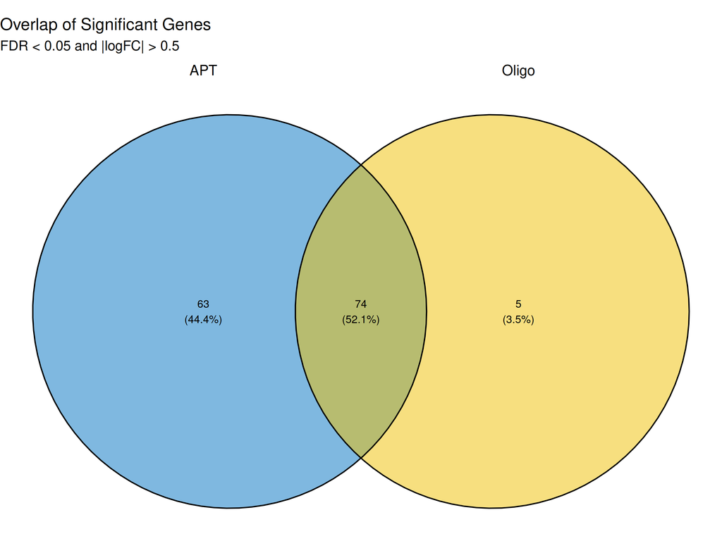

Venn Diagram showing the overlap of significant genes (FDR < 0.05, |logFC| > 0.5) between APT and Oligo pipelines.

```r
venn_data <- list(
  APT = apt_sig,
  Oligo = oligo_sig
)

tryCatch({
  venn_plot <- ggvenn(venn_data,
                      fill_color = c("#0073C2FF", "#EFC000FF"), # Example colors
                      stroke_size = 0.5,
                      set_name_size = 4,
                      text_size = 3) + # Adjusted text_size for counts
    labs(title = "Overlap of Significant Genes",
         subtitle = "FDR < 0.05 and |logFC| > 0.5")
  print(venn_plot)

  ggsave(file.path(plots_output_dir, "venn_diagram_significant_genes.png"),
         venn_plot,
         width = 8,
         height = 6,
         dpi = 300)
}, error = function(e) {
  warning("Error creating or saving Venn diagram: ", e$message)
})
```

### Identify Common and Unique Significant Genes

```r
common_genes <- intersect(apt_sig, oligo_sig)
apt_unique_sig <- setdiff(apt_sig, oligo_sig)
oligo_unique_sig <- setdiff(oligo_sig, apt_sig)
```

### Analysis of Common Significant Genes

For genes found significant in both pipelines, their FDR and logFC values are compared.

#### Data Preparation for Common Genes

```r
# This chunk prepares the data but doesn't produce visible output itself
comparison_data <- NULL # Initialize
if (length(common_genes) > 0) {
  comparison_data <- apt %>%
    filter(GENES %in% common_genes) %>%
    select(GENES, SYMBOL_final, ENSEMBL_final, adj.P.Val, logFC) %>%
    rename(apt_adj.P.Val = adj.P.Val,
           apt_logFC = logFC) %>%
    left_join(
      oligo %>%
        filter(GENES %in% common_genes) %>%
        select(GENES, adj.P.Val, logFC) %>%
        rename(oligo_adj.P.Val = adj.P.Val,
               oligo_logFC = logFC),
      by = "GENES"
    )

  # Save the detailed common genes comparison table
  tryCatch({
    write_csv(comparison_data, file.path(tables_output_dir, "common_significant_genes_comparison.csv"))
    cat(paste0("\nTable of common significant genes saved to: ",
               file.path(tables_output_dir, "common_significant_genes_comparison.csv"), "\n"))
  }, error = function(e) {
    warning("Error saving common significant genes table: ", e$message)
  })
} else {
  cat("\nNo common significant genes found to create comparison data.\n")
}
```

```
Table of common significant genes saved to: venny_analysis_output_spin/tables/common_significant_genes_comparison.csv
```

#### Comparison Plots for Common Genes

Scatter plots compare FDR and logFC values for the common significant genes.

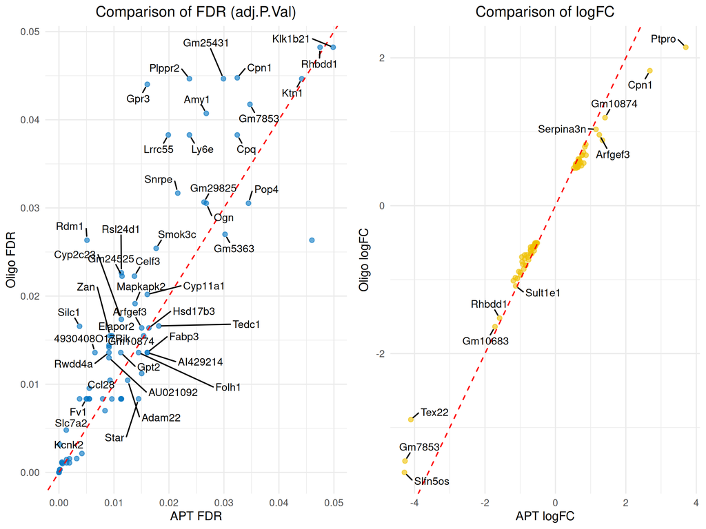

Comparison of FDR (left) and logFC (right) for genes significant in both APT and Oligo pipelines. Points are labeled with gene symbols.

```r
if (!is.null(comparison_data) && nrow(comparison_data) > 0) {
  tryCatch({
    fdr_plot <- ggplot(comparison_data,
                       aes(x = apt_adj.P.Val, y = oligo_adj.P.Val, label = SYMBOL_final)) +
      geom_point(alpha = 0.6, color = "#0073C2FF") +
      geom_abline(intercept = 0, slope = 1, linetype = "dashed", color = "red") +
      geom_text_repel(size = 3, max.overlaps = 20, min.segment.length = 0.1,
                      box.padding = 0.5, point.padding = 0.2) +
      labs(title = "Comparison of FDR (adj.P.Val)",
           x = "APT FDR",
           y = "Oligo FDR") +
      theme_minimal(base_size = 10) + # Adjusted base_size
      theme(plot.title = element_text(hjust = 0.5))

    logfc_plot <- ggplot(comparison_data,
                         aes(x = apt_logFC, y = oligo_logFC, label = SYMBOL_final)) +
      geom_point(alpha = 0.6, color = "#EFC000FF") +
      geom_abline(intercept = 0, slope = 1, linetype = "dashed", color = "red") +
      geom_text_repel(size = 3, max.overlaps = 20, min.segment.length = 0.1,
                      box.padding = 0.5, point.padding = 0.2) +
      labs(title = "Comparison of logFC",
           x = "APT logFC",
           y = "Oligo logFC") +
      theme_minimal(base_size = 10) + # Adjusted base_size
      theme(plot.title = element_text(hjust = 0.5))

    combined_plot <- ggarrange(fdr_plot, logfc_plot, ncol = 2)
    print(combined_plot)

    ggsave(file.path(plots_output_dir, "common_genes_fdr_logfc_comparison.png"),
           combined_plot,
           width = 12, # Adjusted width
           height = 6, # Adjusted height
           dpi = 300)
  }, error = function(e) {
    warning("Error creating or saving comparison plots for common genes: ", e$message)
  })
} else {
  cat("\nSkipping comparison plots as no common significant genes were found.\n")
}
```

### Analysis of Unique Significant Genes

Tables are generated for genes found significant exclusively in either the APT or Oligo pipeline.

#### Table of Unique APT Significant Genes

```r
apt_unique_df <- NULL # Initialize
if (length(apt_unique_sig) > 0) {
  tryCatch({
    apt_unique_df <- apt %>%
      filter(GENES %in% apt_unique_sig) %>%
      select(GENES, SYMBOL_final, ENSEMBL_final, logFC, adj.P.Val)
    write_csv(apt_unique_df, file.path(tables_output_dir, "unique_apt_significant_genes.csv"))
    cat(paste0("\nTable of unique APT significant genes saved to: ",
               file.path(tables_output_dir, "unique_apt_significant_genes.csv"), "\n"))
    #' Displaying first few unique APT genes (if any):
    if (!is.null(apt_unique_df)) knitr::kable(head(apt_unique_df), caption = "First 6 Unique APT Significant Genes")
  }, error = function(e) {
    warning("Error creating or saving table for unique APT genes: ", e$message)
  })
} else {
  cat("\nNo unique significant genes found for APT.\n")
  # Create an empty file or a file with a message if you prefer
  # write_lines("No unique significant genes found for APT.", file.path(tables_output_dir, "unique_apt_significant_genes.csv"))
}
```

```
Table of unique APT significant genes saved to: venny_analysis_output_spin/tables/unique_apt_significant_genes.csv
```

First 6 Unique APT Significant Genes

| GENES | SYMBOL_final | ENSEMBL_final | logFC | adj.P.Val |
| --- | --- | --- | --- | --- |
| Gdpd3_ENSMUSG00000030703 | Gdpd3 | ENSMUSG00000030703 | -0.7517587 | 0.0050939 |
| Shisa7_ENSMUSG00000053550 | Shisa7 | ENSMUSG00000053550 | 0.5274730 | 0.0230966 |
| Nlrc5_ENSMUSG00000074151 | Nlrc5 | ENSMUSG00000074151 | 0.5202448 | 0.0160637 |
| Stox2_ENSMUSG00000038143 | Stox2 | ENSMUSG00000038143 | 0.7012181 | 0.0301953 |
| Calml4_ENSMUSG00000032246 | Calml4 | ENSMUSG00000032246 | -0.7664031 | 0.0011074 |
| Ctsh_ENSMUSG00000032359 | Ctsh | ENSMUSG00000032359 | -0.5075871 | 0.0160637 |

#### Table of Unique Oligo Significant Genes

```r
oligo_unique_df <- NULL # Initialize
if (length(oligo_unique_sig) > 0) {
  tryCatch({
    oligo_unique_df <- oligo %>%
      filter(GENES %in% oligo_unique_sig) %>%
      select(GENES, SYMBOL_final, ENSEMBL_final, logFC, adj.P.Val)
    write_csv(oligo_unique_df, file.path(tables_output_dir, "unique_oligo_significant_genes.csv"))
    cat(paste0("\nTable of unique Oligo significant genes saved to: ",
               file.path(tables_output_dir, "unique_oligo_significant_genes.csv"), "\n"))
    #' Displaying first few unique Oligo genes (if any):
    if(!is.null(oligo_unique_df)) knitr::kable(head(oligo_unique_df), caption = "First 6 Unique Oligo Significant Genes")
  }, error = function(e) {
    warning("Error creating or saving table for unique Oligo genes: ", e$message)
  })
} else {
  cat("\nNo unique significant genes found for Oligo.\n")
  # write_lines("No unique significant genes found for Oligo.", file.path(tables_output_dir, "unique_oligo_significant_genes.csv"))
}
```

```
Table of unique Oligo significant genes saved to: venny_analysis_output_spin/tables/unique_oligo_significant_genes.csv
```

First 6 Unique Oligo Significant Genes

| GENES | SYMBOL_final | ENSEMBL_final | logFC | adj.P.Val |
| --- | --- | --- | --- | --- |
| Nmur1_ENSMUSG00000026237 | Nmur1 | ENSMUSG00000026237 | 0.5375974 | 0.0063592 |
| Tbc1d7_ENSMUSG00000021368 | Tbc1d7 | ENSMUSG00000021368 | -0.5147249 | 0.0473468 |
| Ndufs5-ps_NA | Ndufs5-ps | NA | -0.5422194 | 0.0430364 |
| 1700073E17Rik_NA | 1700073E17Rik | NA | -0.5713226 | 0.0214485 |
| Capza1b_ENSMUSG00000055357 | Capza1b | ENSMUSG00000055357 | -4.4099650 | 0.0255814 |

### Summary Statistics

A summary of the number of significant genes in each dataset and their overlap.

```r
# The cat calls will output to the R Markdown document
cat("\nSummary Statistics:\n")
```

```
Summary Statistics:
```

```r
cat("-------------------\n")
cat("* APT significant genes (FDR < 0.05, |logFC| > 0.5):", length(apt_sig), "\n")
```

```
* APT significant genes (FDR < 0.05, |logFC| > 0.5): 137
```

```r
cat("* Oligo significant genes (FDR < 0.05, |logFC| > 0.5):", length(oligo_sig), "\n")
```

```
* Oligo significant genes (FDR < 0.05, |logFC| > 0.5): 79
```

```r
cat("* Overlapping significant genes:", length(common_genes), "\n")
```

```
* Overlapping significant genes: 74
```

```r
cat("* Unique APT significant genes:", length(apt_unique_sig), "\n")
```

```
* Unique APT significant genes: 63
```

```r
cat("* Unique Oligo significant genes:", length(oligo_unique_sig), "\n")
```

```
* Unique Oligo significant genes: 5
```

Saving summary statistics to a text file.

```r
summary_file_path <- file.path(tables_output_dir, "summary_statistics.txt")
tryCatch({
  # Using write_lines for more direct control over file content
  summary_content <- c(
    "Summary Statistics:",
    "-------------------",
    paste("APT significant genes (FDR < 0.05, |logFC| > 0.5):", length(apt_sig)),
    paste("Oligo significant genes (FDR < 0.05, |logFC| > 0.5):", length(oligo_sig)),
    paste("Overlapping significant genes:", length(common_genes)),
    paste("Unique APT significant genes:", length(apt_unique_sig)),
    paste("Unique Oligo significant genes:", length(oligo_unique_sig))
  )
  write_lines(summary_content, summary_file_path)
  cat(paste0("\nSummary statistics also saved to text file: ", summary_file_path, "\n"))
}, error = function(e) {
  warning("Error writing summary statistics to file: ", e$message)
})
```

```
Summary statistics also saved to text file: venny_analysis_output_spin/tables/summary_statistics.txt
```

Venny analysis script finished. Outputs are saved in the ‘venny_analysis_output_spin’ directory.